# HW Week 7

Brandon Brenes

2024-10-10

## **Description**

For today’s homework, I will attempt to create a map showing the distribution of meteors in the US. This map will also display the relative mass of the meteor that struck in that particular region. To do so, we will be using the *mapdata* (later converted into *states and USA map data*) and *meteor data* coupled with the **geom_polygon()** and **geom_point()** functions.

### 1. Libraries

We won’t get too far without libraries, so let’s load some! Here are the ones we’ll be using to create these maps:

```r
## libraries ##

library(tidyverse)
library(here)
library(maps)
library(mapdata)
library(mapproj)
library(readr)
```

### 2. Data

The data sets being used involve longitude and latitude coordinates. The *USA data* outlines the United States mainland and the *States data* has longitude and latitude data for each of the states on the mainland. The meteorite data shows the longitude and latitude location of where they landed and the mass of each of those meteors.

```r
## load data ##


# USA map data & states data

USA<-map_data("usa") #of the map_data use the USA data
states <- map_data("state") #of the map_data use the state data

# meteorite data

meteorites <- readr::read_csv("https://raw.githubusercontent.com/rfordatascience/tidytuesday/master/data/2019/2019-06-11/meteorites.csv")

#restrict meteorite data to within USA

meteorites <- meteorites[meteorites$long >= -125 & meteorites$long <= -66 &
                          meteorites$lat >= 24 & meteorites$lat <= 50, ]
```

#### Take a peek of the data…

**USA data:**

```r
# view data #
glimpse(USA)
```

```
## Rows: 7,243
## Columns: 6
## $ long      <dbl> -101.4078, -101.3906, -101.3620, -101.3505, -101.3219, -101.…
## $ lat       <dbl> 29.74224, 29.74224, 29.65056, 29.63911, 29.63338, 29.64484, …
## $ group     <dbl> 1, 1, 1, 1, 1, 1, 1, 1, 1, 1, 1, 1, 1, 1, 1, 1, 1, 1, 1, 1, …
## $ order     <int> 1, 2, 3, 4, 5, 6, 7, 8, 9, 10, 11, 12, 13, 14, 15, 16, 17, 1…
## $ region    <chr> "main", "main", "main", "main", "main", "main", "main", "mai…
## $ subregion <chr> NA, NA, NA, NA, NA, NA, NA, NA, NA, NA, NA, NA, NA, NA, NA, …
```

**States data:**

```r
# view data #
glimpse(states)
```

```
## Rows: 15,537
## Columns: 6
## $ long      <dbl> -87.46201, -87.48493, -87.52503, -87.53076, -87.57087, -87.5…
## $ lat       <dbl> 30.38968, 30.37249, 30.37249, 30.33239, 30.32665, 30.32665, …
## $ group     <dbl> 1, 1, 1, 1, 1, 1, 1, 1, 1, 1, 1, 1, 1, 1, 1, 1, 1, 1, 1, 1, …
## $ order     <int> 1, 2, 3, 4, 5, 6, 7, 8, 9, 10, 11, 12, 13, 14, 15, 16, 17, 1…
## $ region    <chr> "alabama", "alabama", "alabama", "alabama", "alabama", "alab…
## $ subregion <chr> NA, NA, NA, NA, NA, NA, NA, NA, NA, NA, NA, NA, NA, NA, NA, …
```

**Meteor data:**

```r
# view data #
glimpse(meteorites)
```

```
## Rows: 9,062
## Columns: 10
## $ name        <chr> "Allegan", "Allende", "Andover", "Archie", "Ash Creek", "A…
## $ id          <dbl> 2276, 2278, 2295, 2329, 48954, 4885, 4888, 4907, 4913, 492…
## $ name_type   <chr> "Valid", "Valid", "Valid", "Valid", "Valid", "Valid", "Val…
## $ class       <chr> "H5", "CV3", "L6", "H6", "L6", "LL6", "L6", "H", "L6", "L4…
## $ mass        <dbl> 32000.0, 2000000.0, 3200.0, 5070.0, 9500.0, 265.0, 1384.2,…
## $ fall        <chr> "Fell", "Fell", "Fell", "Fell", "Fell", "Fell", "Fell", "F…
## $ year        <dbl> 1899, 1969, 1898, 1932, 2009, 1933, 1945, 1855, 1938, 1929…
## $ lat         <dbl> 42.53333, 26.96667, 44.61667, 38.50000, 31.80500, 34.75000…
## $ long        <dbl> -85.88333, -105.31667, -70.75000, -94.30000, -97.01000, -8…
## $ geolocation <chr> "(42.53333, -85.88333)", "(26.96667, -105.31667)", "(44.61…
```

### 3. Meteor map

To create this map we will be using the *USA data* superimposed with the *States data* using the **geom_polygon()** function. I then used the **scale_size_continuous** and **labs()** function to express the relationship between the size of the point and the mass of the meteor.

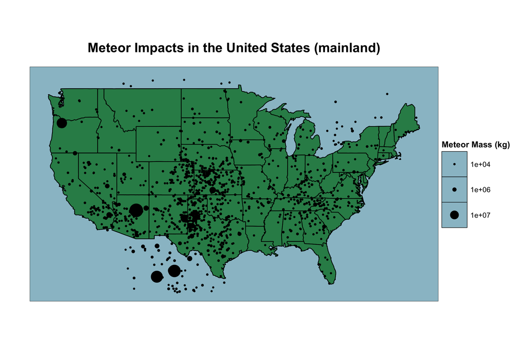

```r
ggplot() +
  geom_polygon(data = USA, #using the USA lat/long data and geom_polygon function to create shape of USA
               aes(x = long, y = lat, group = group), #assign x-y to lat and long
               fill = "seagreen", color = "black") + #fill the USA mainland outline with color and outline with black
  geom_polygon(data = states, #use state lat/long data
               aes(x = long, y = lat, group = group), #assign x-y to lat and long
               fill = NA, color = "black") + #outline states in black
  theme_light() + #light theme
  coord_map(projection = "mercator") + #use mercator style for mapping
  theme_void() + #get rid of axis for lat and long
  theme(panel.background = element_rect(fill = "lightblue3"))+ #fill outside background with blue
  geom_point(data = meteorites, #using geom_point
             aes(x = long, y = lat, size = mass))+ #assign x-y to lat and long, size of point associated by mass
   scale_size_continuous( #scale_size_continuous() legend customization
    name = "Meteor Mass (kg)", #title legend
    breaks = c(1e4, 1e6, 1e7), #add three breaks
    range = c(1, 10) #range the size of points
  ) +
  labs(title = "Meteor Impacts in the United States (mainland)", size = "Meteor Mass (kg)")+ #titles
  theme(plot.title = element_text(hjust = 0.5, size = 22, face = "bold", margin = margin(b = 20)),
                                  plot.margin = margin(t = 10, r = 10, b = 10, l = 50), #add margins
legend.title = element_text(size = 14, face = "bold"), #legend title characters
    legend.text = element_text(size = 12), #size subtitle characters
    legend.key.size = unit(1.5, 'cm')
  )
```